# chapter 9-2

Min-Yao

2019年9月26日

```r
library(rethinking)
library(rstan)
```

# 9 Markov Chain Monte Carlo

## 9.1. Good King Markov and His island kingdom

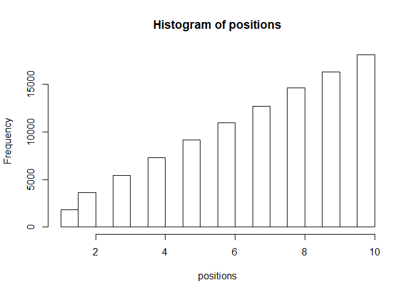

```r
## R code 9.1
num_weeks <- 1e5
positions <- rep(0,num_weeks)
current <- 10
for ( i in 1:num_weeks ) {
    # record current position
    positions[i] <- current

    # flip coin to generate proposal
    proposal <- current + sample( c(-1,1) , size=1 )
    # now make sure he loops around the archipelago
    if ( proposal < 1 ) proposal <- 10
    if ( proposal > 10 ) proposal <- 1

    # move?
    prob_move <- proposal/current
    current <- ifelse( runif(1) < prob_move , proposal , current )
}
hist(positions)
```

## 9.2. Metropolis, Gibbs, and Sadness

### 9.2.1. Gibbs sampling.

### 9.2.2. High-dimensional sadness.

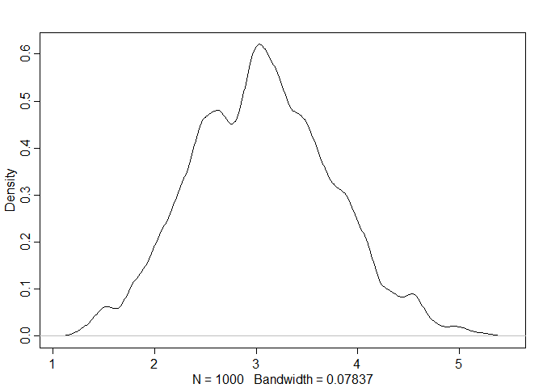

```r
## R code 9.2
D <- 10
T <- 1e3
Y <- rmvnorm(T,rep(0,D),diag(D))
rad_dist <- function( Y ) sqrt( sum(Y^2) )
Rd <- sapply( 1:T , function(i) rad_dist( Y[i,] ) )
dens( Rd )
```

## 9.3. Hamiltonian Monte Carlo

### 9.3.1. Another parable.

### 9.3.2. Particles in space.

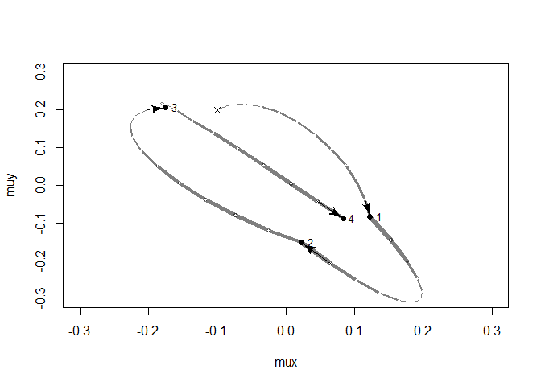

```r
## R code 9.3
# U needs to return neg-log-probability
myU4 <- function( q , a=0 , b=1 , k=0 , d=1 ) {
    muy <- q[1]
    mux <- q[2]
    U <- sum( dnorm(y,muy,1,log=TRUE) ) + sum( dnorm(x,mux,1,log=TRUE) ) +
        dnorm(muy,a,b,log=TRUE) + dnorm(mux,k,d,log=TRUE)
    return( -U )
}

## R code 9.4
# gradient function
# need vector of partial derivatives of U with respect to vector q
myU_grad4 <- function( q , a=0 , b=1 , k=0 , d=1 ) {
    muy <- q[1]
    mux <- q[2]
    G1 <- sum( y - muy ) + (a - muy)/b^2 #dU/dmuy
    G2 <- sum( x - mux ) + (k - mux)/d^2 #dU/dmuy
    return( c( -G1 , -G2 ) ) # negative bc energy is neg-log-prob
}
# test data
set.seed(7)
y <- rnorm(50)
x <- rnorm(50)
x <- as.numeric(scale(x))
y <- as.numeric(scale(y))

## R code 9.5
library(shape) # for fancy arrows
Q <- list()
Q$q <- c(-0.1,0.2)
pr <- 0.3
plot( NULL , ylab="muy" , xlab="mux" , xlim=c(-pr,pr) , ylim=c(-pr,pr) )
step <- 0.03
L <- 11 # 0.03/28 for U-turns --- 11 for working example
n_samples <- 4
path_col <- col.alpha("black",0.5)
points( Q$q[1] , Q$q[2] , pch=4 , col="black" )
for ( i in 1:n_samples ) {
    Q <- HMC2( myU4 , myU_grad4 , step , L , Q$q )
    if ( n_samples < 10 ) {
      for ( j in 1:L ) {
        K0 <- sum(Q$ptraj[j,]^2)/2 # kinetic energy
        lines( Q$traj[j:(j+1),1] , Q$traj[j:(j+1),2] , col=path_col , lwd=1+2*K0 )
      }
      points( Q$traj[1:L+1,] , pch=16 , col="white" , cex=0.35 )
      Arrows( Q$traj[L,1] , Q$traj[L,2] , Q$traj[L+1,1] , Q$traj[L+1,2] ,
          arr.length=0.35 , arr.adj = 0.7 )
      text( Q$traj[L+1,1] , Q$traj[L+1,2] , i , cex=0.8 , pos=4 , offset=0.4 )
    }
    points( Q$traj[L+1,1] , Q$traj[L+1,2] , pch=ifelse( Q$accept==1 , 16 , 1 ) ,
        col=ifelse( abs(Q$dH)>0.1 , "red" , "black" ) )
}
```

```r
## R code 9.6
HMC2 <- function (U, grad_U, epsilon, L, current_q) {
  q = current_q
  p = rnorm(length(q),0,1) # random flick - p is momentum.
  current_p = p
  # Make a half step for momentum at the beginning
  p = p - epsilon * grad_U(q) / 2
  # initialize bookkeeping - saves trajectory
  qtraj <- matrix(NA,nrow=L+1,ncol=length(q))
  ptraj <- qtraj
  qtraj[1,] <- current_q
  ptraj[1,] <- p

## R code 9.7
  # Alternate full steps for position and momentum
  for ( i in 1:L ) {
    q = q + epsilon * p # Full step for the position
    # Make a full step for the momentum, except at end of trajectory
    if ( i!=L ) {
        p = p - epsilon * grad_U(q)
        ptraj[i+1,] <- p
    }
    qtraj[i+1,] <- q
  }

## R code 9.8
  # Make a half step for momentum at the end
  p = p - epsilon * grad_U(q) / 2
  ptraj[L+1,] <- p
  # Negate momentum at end of trajectory to make the proposal symmetric
  p = -p
  # Evaluate potential and kinetic energies at start and end of trajectory
  current_U = U(current_q)
  current_K = sum(current_p^2) / 2
  proposed_U = U(q)
  proposed_K = sum(p^2) / 2
  # Accept or reject the state at end of trajectory, returning either
  # the position at the end of the trajectory or the initial position
  accept <- 0
  if (runif(1) < exp(current_U-proposed_U+current_K-proposed_K)) {
    new_q <- q  # accept
    accept <- 1
  } else new_q <- current_q  # reject
  return(list( q=new_q, traj=qtraj, ptraj=ptraj, accept=accept ))
}
```

### 9.3.3. Limitations.

## 9.4. Easy HMC: ulam

```r
## R code 9.9
library(rethinking)
data(rugged)
d <- rugged
d$log_gdp <- log(d$rgdppc_2000)
dd <- d[ complete.cases(d$rgdppc_2000) , ]
dd$log_gdp_std <- dd$log_gdp / mean(dd$log_gdp)
dd$rugged_std <- dd$rugged / max(dd$rugged)
dd$cid <- ifelse( dd$cont_africa==1 , 1 , 2 )

## R code 9.10
m8.5 <- quap(
    alist(
        log_gdp_std ~ dnorm( mu , sigma ) ,
        mu <- a[cid] + b[cid]*( rugged_std - 0.215 ) ,
        a[cid] ~ dnorm( 1 , 0.1 ) ,
        b[cid] ~ dnorm( 0 , 0.3 ) ,
        sigma ~ dexp( 1 )
    ) ,
    data=dd )
precis( m8.5 , depth=2 )
```

```
##             mean          sd        5.5%       94.5%
## a[1]   0.8865640 0.015674552  0.86151302  0.91161495
## a[2]   1.0505666 0.009935872  1.03468714  1.06644602
## b[1]   0.1324981 0.074199237  0.01391344  0.25108286
## b[2]  -0.1426057 0.054745410 -0.23009945 -0.05511197
## sigma  0.1094859 0.005934188  0.10000194  0.11896990
```

### 9.4.1. Preparation.

```r
## R code 9.11
dat_slim <- list(
    log_gdp_std = dd$log_gdp_std,
    rugged_std = dd$rugged_std,
    cid = as.integer( dd$cid )
)
str(dat_slim)
```

```
## List of 3
##  $ log_gdp_std: num [1:170] 0.88 0.965 1.166 1.104 0.915 ...
##  $ rugged_std : num [1:170] 0.138 0.553 0.124 0.125 0.433 ...
##  $ cid        : int [1:170] 1 2 2 2 2 2 2 2 2 1 ...
```

```r
library(rstan)

## R code 9.12
m9.1 <- ulam(
    alist(
        log_gdp_std ~ dnorm( mu , sigma ) ,
        mu <- a[cid] + b[cid]*( rugged_std - 0.215 ) ,
        a[cid] ~ dnorm( 1 , 0.1 ) ,
        b[cid] ~ dnorm( 0 , 0.3 ) ,
        sigma ~ dexp( 1 )
    ) ,
    data=dat_slim , chains=1 )
## R code 9.13
precis( m9.1 , depth=2 )
```

```
##             mean          sd       5.5%       94.5%    n_eff      Rhat
## a[1]   0.8860276 0.015017334  0.8610820  0.90935448 611.9029 0.9992640
## a[2]   1.0507103 0.009962509  1.0346462  1.06597616 758.1026 0.9983919
## b[1]   0.1283696 0.069453611  0.0178113  0.23858296 383.5598 0.9991305
## b[2]  -0.1441684 0.054272764 -0.2330822 -0.05543733 651.4452 0.9987844
## sigma  0.1110400 0.005960409  0.1021757  0.12117579 693.2185 0.9997997
```

### 9.4.3. Sampling again, in parallel.

```r
## R code 9.14
m9.1 <- ulam(
    alist(
        log_gdp_std ~ dnorm( mu , sigma ) ,
        mu <- a[cid] + b[cid]*( rugged_std - 0.215 ) ,
        a[cid] ~ dnorm( 1 , 0.1 ) ,
        b[cid] ~ dnorm( 0 , 0.3 ) ,
        sigma ~ dexp( 1 )
    ) ,
    data=dat_slim , chains=4 , cores=4 , iter=1000 )
```

```
## recompiling to avoid crashing R session
```

```r
## R code 9.15
show( m9.1 )
```

```
## Hamiltonian Monte Carlo approximation
## 2000 samples from 4 chains
##
## Sampling durations (seconds):
##         warmup sample total
## chain:1   0.10   0.07  0.17
## chain:2   0.19   0.11  0.30
## chain:3   0.11   0.08  0.19
## chain:4   0.09   0.06  0.15
##
## Formula:
## log_gdp_std ~ dnorm(mu, sigma)
## mu <- a[cid] + b[cid] * (rugged_std - 0.215)
## a[cid] ~ dnorm(1, 0.1)
## b[cid] ~ dnorm(0, 0.3)
## sigma ~ dexp(1)
```

```r
## R code 9.16
precis( m9.1 , 2 )
```

```
##             mean          sd         5.5%       94.5%    n_eff      Rhat
## a[1]   0.8864428 0.016284165  0.859943580  0.91291113 2632.242 0.9986519
## a[2]   1.0507178 0.010446356  1.034351525  1.06743151 2894.188 1.0000595
## b[1]   0.1316973 0.077286606  0.004242543  0.25560170 2333.190 0.9998321
## b[2]  -0.1426273 0.056011176 -0.229962049 -0.05168892 2801.616 1.0007067
## sigma  0.1117562 0.006122426  0.102490248  0.12173577 2010.857 0.9996732
```

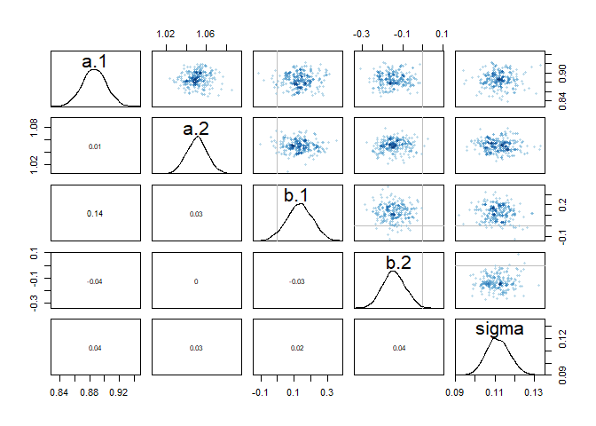

```r
## R code 9.17
pairs( m9.1 )
```

### 9.4.5. Checking the chain.

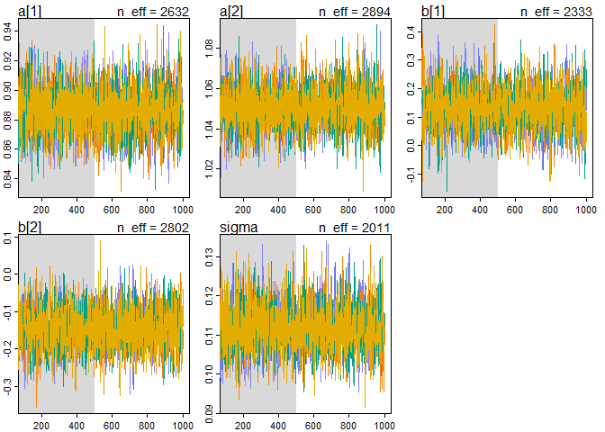

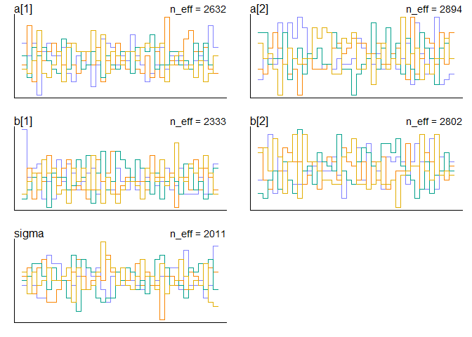

```r
## R code 9.18
traceplot( m9.1 )
trankplot( m9.1 , n_cols=2 )
```

## 9.5. Care and feeding of your Markov chain

### 9.5.1. How many samples do you need?

### 9.5.2. How many chains do you need?

### 9.5.3. Taming a wild chain.

```r
## R code 9.19
y <- c(1.000001,-1.000001)
set.seed(11)

m9.2 <- ulam(
    alist(
        y ~ dnorm( mu , sigma ) ,
        mu <- alpha ,
        alpha ~ dnorm( 0 , 1000 ) ,
        sigma ~ dexp( 0.0001 )
    ) ,
    data=list(y=y) , chains=2 )
## R code 9.20
precis( m9.2 )
```

```
##            mean        sd        5.5%     94.5%     n_eff     Rhat
## alpha  59.38425  394.4026 -334.724932  726.1444  78.40695 1.019956
## sigma 761.70657 2056.2837    5.714878 3209.5629 126.43502 1.009607
```

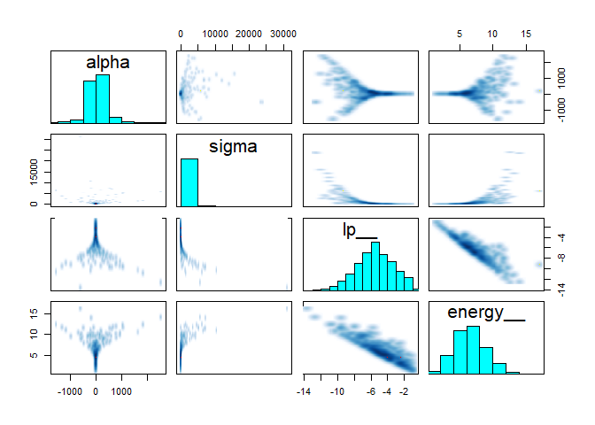

```r
pairs(m9.2@stanfit)
```

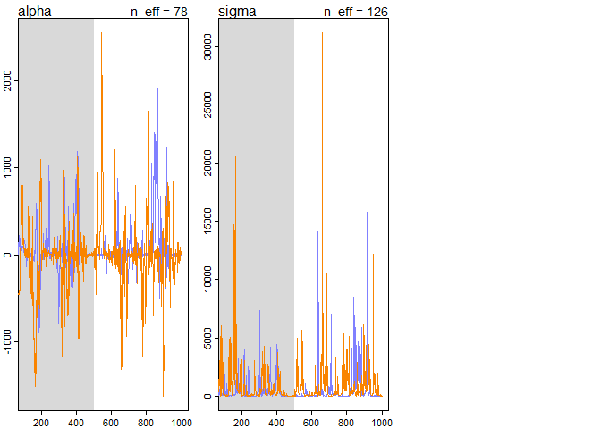

```r
traceplot(m9.2)
```

```r
## R code 9.21
set.seed(11)
m9.3 <- ulam(
    alist(
        y ~ dnorm( mu , sigma ) ,
        mu <- alpha ,
        alpha ~ dnorm( 1 , 10 ) ,
        sigma ~ dexp( 1 )
    ) ,
    data=list(y=y) , chains=2 )
precis( m9.3 )
```

```
##             mean        sd       5.5%    94.5%    n_eff     Rhat
## alpha -0.1434589 1.2328258 -2.1110053 1.619507 275.6055 1.000705
## sigma  1.5653786 0.8405426  0.6544161 3.185414 215.5023 1.003858
```

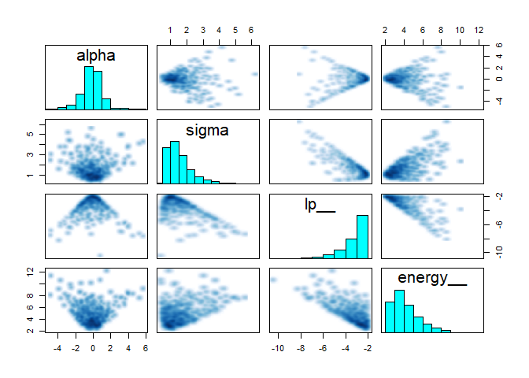

```r
pairs(m9.3@stanfit)
```

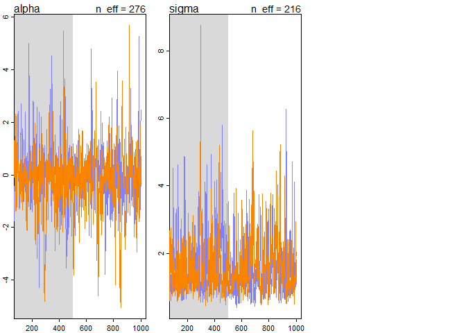

```r
traceplot(m9.3)
```

### 9.5.4. Non-identifiable parameters.

```r
## R code 9.22
set.seed(41)
y <- rnorm( 100 , mean=0 , sd=1 )

## R code 9.23
m9.4 <- ulam(
    alist(
        y ~ dnorm( mu , sigma ) ,
        mu <- a1 + a2 ,
        a1 ~ dnorm( 0 , 1000 ),
        a2 ~ dnorm( 0 , 1000 ),
        sigma ~ dexp( 1 )
    ) ,
    data=list(y=y) , chains=2 )
precis( m9.4 )
```

```
##              mean           sd          5.5%       94.5%    n_eff     Rhat
## a1    -647.972890 246.15123408 -1031.3053795 -289.083627 1.977311 1.641353
## a2     648.165109 246.15155921   289.2819267 1031.524094 1.977290 1.641338
## sigma    1.026928   0.07054863     0.9272982    1.165109 4.069786 1.444470
```

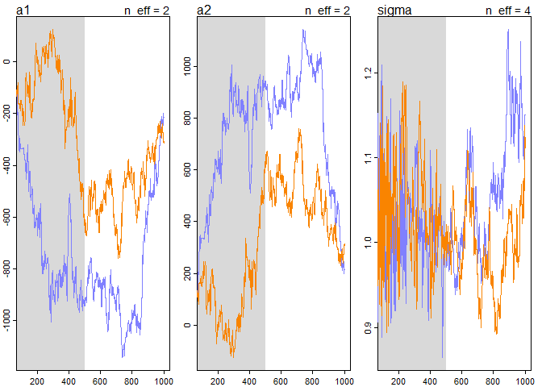

```r
traceplot(m9.4)
```

```r
## R code 9.23
m9.4.2 <- ulam(
    alist(
        y ~ dnorm( mu , sigma ) ,
        mu <- a1 + a2 ,
        a1 ~ dnorm( 0 , 1000 ),
        a2 ~ dnorm( 0 , 1000 ),
        sigma ~ dexp( 1 )
    ) ,
    data=list(y=y) , chains=2 , control = list(max_treedepth=15))
```

```
## recompiling to avoid crashing R session
```

```r
precis( m9.4.2 )
```

```
##            mean           sd          5.5%       94.5%    n_eff     Rhat
## a1    -2.846370 714.87772229 -1038.0764013 1146.202166 173.0693 1.007198
## a2     3.036046 714.87616587 -1145.9703863 1038.176004 173.0738 1.007199
## sigma  1.032415   0.07976383     0.9095945    1.160942 326.9122 1.002502
```

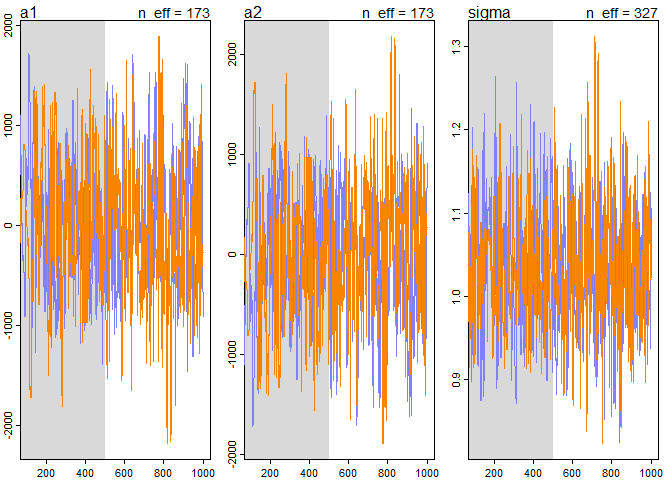

```r
traceplot(m9.4.2)
```

```r
## R code 9.24
m9.5 <- ulam(
    alist(
        y ~ dnorm( mu , sigma ) ,
        mu <- a1 + a2 ,
        a1 ~ dnorm( 0 , 10 ),
        a2 ~ dnorm( 0 , 10 ),
        sigma ~ dexp( 1 )
    ) ,
    data=list(y=y) , chains=2 )
precis( m9.5 )
```

```
##              mean         sd        5.5%     94.5%    n_eff     Rhat
## a1     0.22938288 6.55984510 -10.5266256 10.654199 341.1499 1.003040
## a2    -0.04112721 6.55712824 -10.4846416 10.690694 341.9746 1.003088
## sigma  1.04469079 0.06887638   0.9412379  1.157347 271.1016 1.006299
```

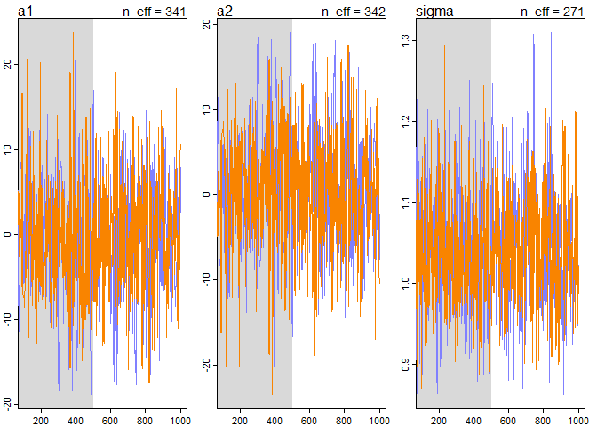

```r
traceplot(m9.5)
```

## 9.6. Summary

## 9.7. Practice

### Easy.

#### 8E2. Gibbs sampling is more efficient than the Metropolis algorithm. How does it achieve this extra efficiency? Are there any limitations to the Gibbs sampling strategy?

> The improvement arises from adaptive proposals in which the distribution of proposed parameter values adjusts itself intelligently, depending upon the parameter values at the moment.

#### 8E3. Which sort of parameters can Hamiltonian Monte Carlo not handle? Can you explain why?

> HMC requires continuous parameters. It can’t glide through a discrete parameter.

### 8E4. Explain the diff erence between the effective number of samples, n_eff as calculated by Stan, and the actual number of samples.

> The effective number of samples is an estimate of the number of independent samples from the posterior distribution. Ideal samples should be entirely uncorrelated. Markov chains are typically autocorrelated, so that sequential samples are not entirely independent. Stan chains tend to be less autocorrelated than those produced by other engines, but there is always some autocorrelation. Stan provides an estimate of effective number of samples as n_eff.

#### 8M1. Re-estimate the terrain ruggedness model from the chapter, but now using a uniform prior and an exponential prior for the standard deviation, sigma. The uniform prior should be dunif(0,10) and the exponential should be dexp(1). Do the different priors have any detectible influence on the posterior distribution?

```r
## R code 9.9
library(rethinking)
data(rugged)
d <- rugged
d$log_gdp <- log(d$rgdppc_2000)
dd <- d[ complete.cases(d$rgdppc_2000) , ]
dd$log_gdp_std <- dd$log_gdp / mean(dd$log_gdp)
dd$rugged_std <- dd$rugged / max(dd$rugged)
dd$cid <- ifelse( dd$cont_africa==1 , 1 , 2 )
```

```r
## R code 9.11
dat_slim <- list(
    log_gdp_std = dd$log_gdp_std,
    rugged_std = dd$rugged_std,
    cid = as.integer( dd$cid )
)
str(dat_slim)
```

```
## List of 3
##  $ log_gdp_std: num [1:170] 0.88 0.965 1.166 1.104 0.915 ...
##  $ rugged_std : num [1:170] 0.138 0.553 0.124 0.125 0.433 ...
##  $ cid        : int [1:170] 1 2 2 2 2 2 2 2 2 1 ...
```

```r
library(rstan)

## R code 9.14
m9.1 <- ulam(
    alist(
        log_gdp_std ~ dnorm( mu , sigma ) ,
        mu <- a[cid] + b[cid]*( rugged_std - 0.215 ) ,
        a[cid] ~ dnorm( 1 , 0.1 ) ,
        b[cid] ~ dnorm( 0 , 0.3 ) ,
        sigma ~ dexp( 1 )
    ) ,
    data=dat_slim , chains=4 , cores=4 , iter=1000 )
```

```
## recompiling to avoid crashing R session
```

```r
## R code 9.15
show( m9.1 )
```

```
## Hamiltonian Monte Carlo approximation
## 2000 samples from 4 chains
##
## Sampling durations (seconds):
##         warmup sample total
## chain:1   0.14   0.10  0.25
## chain:2   0.12   0.13  0.24
## chain:3   0.15   0.10  0.25
## chain:4   0.12   0.08  0.19
##
## Formula:
## log_gdp_std ~ dnorm(mu, sigma)
## mu <- a[cid] + b[cid] * (rugged_std - 0.215)
## a[cid] ~ dnorm(1, 0.1)
## b[cid] ~ dnorm(0, 0.3)
## sigma ~ dexp(1)
```

```r
## R code 9.16
precis( m9.1 , 2 )
```

```
##             mean          sd         5.5%       94.5%    n_eff      Rhat
## a[1]   0.8867219 0.016307649  0.860622815  0.91335040 2302.490 1.0004417
## a[2]   1.0504167 0.009758093  1.034544049  1.06591461 3491.217 0.9984662
## b[1]   0.1345032 0.077765350  0.007548392  0.25534822 2312.001 0.9992399
## b[2]  -0.1439613 0.057818853 -0.232479077 -0.05151766 2565.620 1.0002569
## sigma  0.1117693 0.006277021  0.102286132  0.12216952 2233.835 0.9993693
```

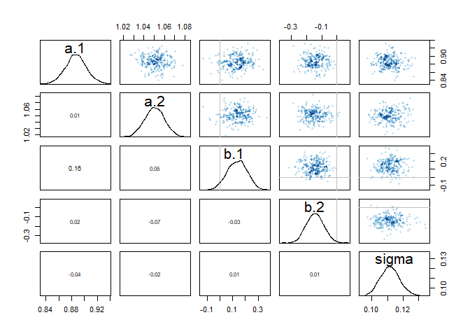

```r
## R code 9.17
pairs( m9.1 )
```

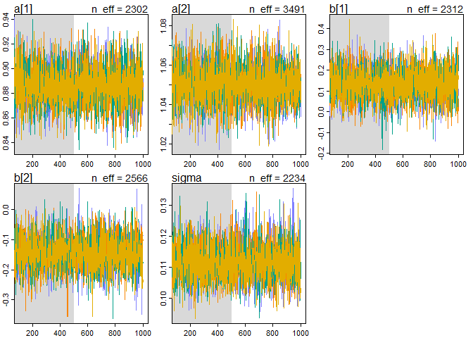

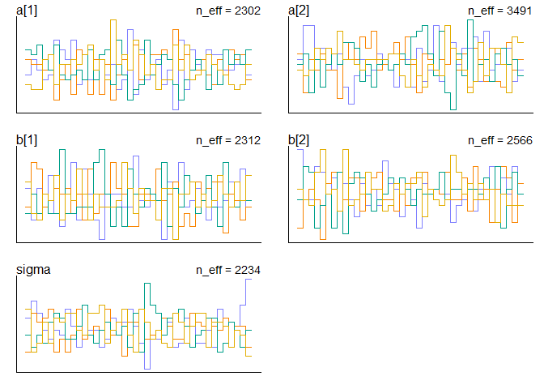

```r
## R code 9.18
traceplot( m9.1 )

trankplot( m9.1 , n_cols=2 )
```

```r
## R code 9.14
m9.1_unif <- ulam(
    alist(
        log_gdp_std ~ dnorm( mu , sigma ) ,
        mu <- a[cid] + b[cid]*( rugged_std - 0.215 ) ,
        a[cid] ~ dnorm( 1 , 0.1 ) ,
        b[cid] ~ dnorm( 0 , 0.3 ) ,
        sigma ~ dunif(0,10)
    ) ,
    data=dat_slim , chains=4 , cores=4 , iter=1000 )

## R code 9.15
show( m9.1_unif )
```

```
## Hamiltonian Monte Carlo approximation
## 2000 samples from 4 chains
##
## Sampling durations (seconds):
##         warmup sample total
## chain:1   0.21   0.12  0.33
## chain:2   0.09   0.06  0.15
## chain:3   0.12   0.08  0.19
## chain:4   0.19   0.23  0.42
##
## Formula:
## log_gdp_std ~ dnorm(mu, sigma)
## mu <- a[cid] + b[cid] * (rugged_std - 0.215)
## a[cid] ~ dnorm(1, 0.1)
## b[cid] ~ dnorm(0, 0.3)
## sigma ~ dunif(0, 10)
```

```r
## R code 9.16
precis( m9.1_unif , 2 )
```

```
##             mean          sd        5.5%       94.5%    n_eff      Rhat
## a[1]   0.8865367 0.015571510  0.86194764  0.91140468 2978.485 0.9998775
## a[2]   1.0508401 0.010418194  1.03440501  1.06771557 3368.347 0.9990657
## b[1]   0.1340269 0.076843348  0.01379107  0.25762209 2633.300 1.0006035
## b[2]  -0.1432294 0.055674470 -0.23073697 -0.05346043 2567.353 0.9998971
## sigma  0.1113296 0.006385865  0.10148157  0.12185025 2517.391 0.9990316
```

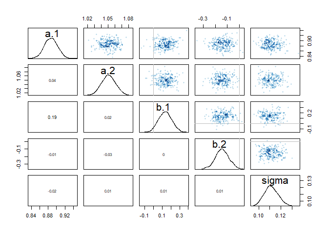

```r
## R code 9.17
pairs( m9.1_unif )
```

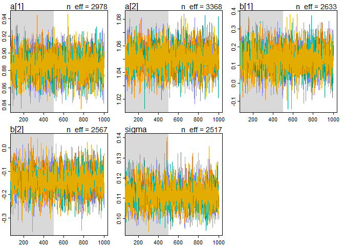

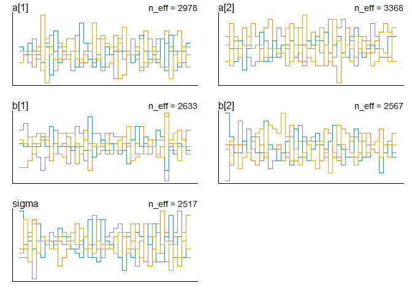

```r
## R code 9.18
traceplot( m9.1_unif )

trankplot( m9.1_unif , n_cols=2 )
```

```r
## R code 9.14
m9.1_cauchy <- ulam(
    alist(
        log_gdp_std ~ dnorm( mu , sigma ) ,
        mu <- a[cid] + b[cid]*( rugged_std - 0.215 ) ,
        a[cid] ~ dnorm( 1 , 0.1 ) ,
        b[cid] ~ dnorm( 0 , 0.3 ) ,
        sigma ~ dcauchy( 0, 1 )
    ) ,
    data=dat_slim , chains=4 , cores=4 , iter=1000 )

## R code 9.15
show( m9.1_cauchy )
```

```
## Hamiltonian Monte Carlo approximation
## 2000 samples from 4 chains
##
## Sampling durations (seconds):
##         warmup sample total
## chain:1   0.12   0.06  0.17
## chain:2   0.12   0.08  0.20
## chain:3   0.10   0.08  0.17
## chain:4   0.12   0.07  0.19
##
## Formula:
## log_gdp_std ~ dnorm(mu, sigma)
## mu <- a[cid] + b[cid] * (rugged_std - 0.215)
## a[cid] ~ dnorm(1, 0.1)
## b[cid] ~ dnorm(0, 0.3)
## sigma ~ dcauchy(0, 1)
```

```r
## R code 9.16
precis( m9.1_cauchy , 2 )
```

```
##             mean          sd        5.5%       94.5%    n_eff      Rhat
## a[1]   0.8870365 0.016003676  0.86137419  0.91230545 2554.909 1.0002880
## a[2]   1.0503319 0.010414065  1.03357276  1.06635822 2974.255 0.9986433
## b[1]   0.1326777 0.075274721  0.01025123  0.25354994 2433.469 0.9995088
## b[2]  -0.1423994 0.053971878 -0.22826566 -0.05675017 2253.079 0.9993371
## sigma  0.1116418 0.005944596  0.10239730  0.12166933 3242.132 1.0005287
```

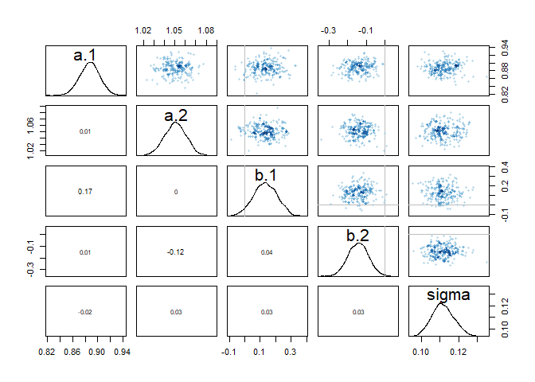

```r
## R code 9.17
pairs( m9.1_cauchy )
```

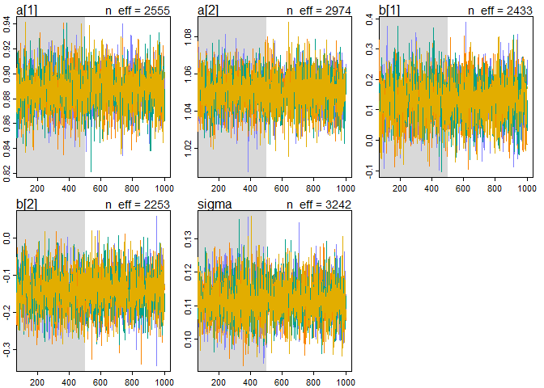

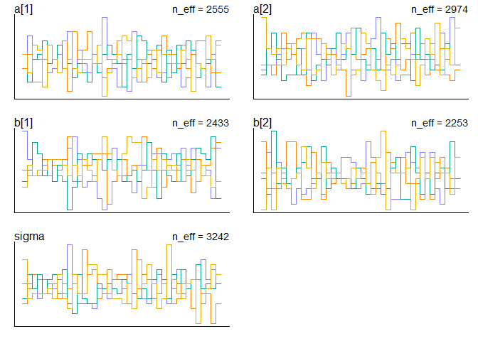

```r
## R code 9.18
traceplot( m9.1_cauchy )

trankplot( m9.1_cauchy , n_cols=2 )
```

#### 8M2. The Cauchy and exponential priors from the terrain ruggedness model are very weak. They can be made more informative by reducing their scale. Compare the dcauchy and dexp priors for progressively smaller values of the scaling parameter. As these priors become stronger, how does each infl uence the posterior distribution?

```r
## R code 9.14
m9.1_0.1 <- ulam(
    alist(
        log_gdp_std ~ dnorm( mu , sigma ) ,
        mu <- a[cid] + b[cid]*( rugged_std - 0.215 ) ,
        a[cid] ~ dnorm( 1 , 0.1 ) ,
        b[cid] ~ dnorm( 0 , 0.3 ) ,
        sigma ~ dexp( 0.1 )
    ) ,
    data=dat_slim , chains=4 , cores=4 , iter=1000 )

## R code 9.15
show( m9.1_0.1 )
```

```
## Hamiltonian Monte Carlo approximation
## 2000 samples from 4 chains
##
## Sampling durations (seconds):
##         warmup sample total
## chain:1   0.10   0.10  0.20
## chain:2   0.08   0.08  0.15
## chain:3   0.10   0.08  0.17
## chain:4   0.16   0.10  0.26
##
## Formula:
## log_gdp_std ~ dnorm(mu, sigma)
## mu <- a[cid] + b[cid] * (rugged_std - 0.215)
## a[cid] ~ dnorm(1, 0.1)
## b[cid] ~ dnorm(0, 0.3)
## sigma ~ dexp(0.1)
```

```r
## R code 9.16
precis( m9.1_0.1 , 2 )
```

```
##             mean          sd        5.5%       94.5%    n_eff      Rhat
## a[1]   0.8861983 0.015798352  0.86161732  0.91173744 2365.583 0.9996843
## a[2]   1.0508876 0.010369200  1.03417996  1.06774408 3163.802 0.9998937
## b[1]   0.1287138 0.074444116  0.01234143  0.24914922 2183.802 1.0014008
## b[2]  -0.1430335 0.057359642 -0.23588839 -0.05239179 2934.495 0.9997149
## sigma  0.1115126 0.006180425  0.10216103  0.12196574 2620.802 1.0012187
```

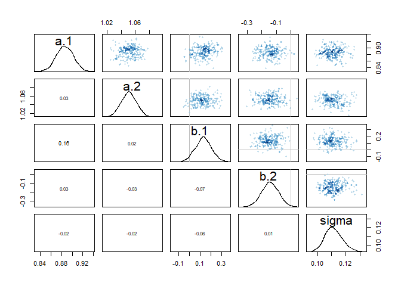

```r
## R code 9.17
pairs( m9.1_0.1 )
```

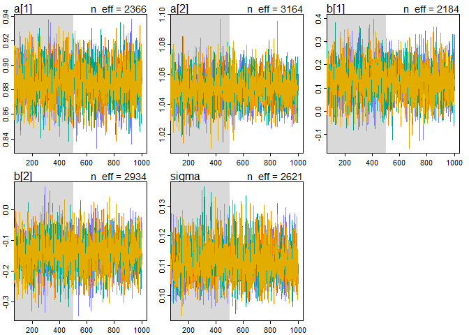

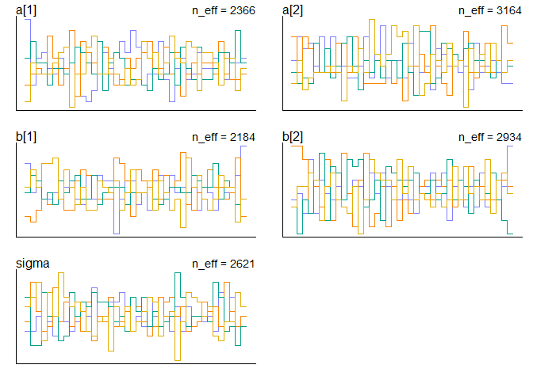

```r
## R code 9.18
traceplot( m9.1_0.1 )

trankplot( m9.1_0.1 , n_cols=2 )
```

```r
## R code 9.14
m9.1_0.01 <- ulam(
    alist(
        log_gdp_std ~ dnorm( mu , sigma ) ,
        mu <- a[cid] + b[cid]*( rugged_std - 0.215 ) ,
        a[cid] ~ dnorm( 1 , 0.1 ) ,
        b[cid] ~ dnorm( 0 , 0.3 ) ,
        sigma ~ dexp( 0.01 )
    ) ,
    data=dat_slim , chains=4 , cores=4 , iter=1000 )

## R code 9.15
show( m9.1_0.01 )
```

```
## Hamiltonian Monte Carlo approximation
## 2000 samples from 4 chains
##
## Sampling durations (seconds):
##         warmup sample total
## chain:1   0.15   0.15  0.30
## chain:2   0.13   0.12  0.26
## chain:3   0.10   0.08  0.18
## chain:4   0.09   0.07  0.16
##
## Formula:
## log_gdp_std ~ dnorm(mu, sigma)
## mu <- a[cid] + b[cid] * (rugged_std - 0.215)
## a[cid] ~ dnorm(1, 0.1)
## b[cid] ~ dnorm(0, 0.3)
## sigma ~ dexp(0.01)
```

```r
## R code 9.16
precis( m9.1_0.01 , 2 )
```

```
##             mean         sd         5.5%       94.5%    n_eff      Rhat
## a[1]   0.8864790 0.01562514  0.861124513  0.91074374 2825.296 0.9990707
## a[2]   1.0505454 0.01029437  1.034339337  1.06700147 3592.879 0.9987981
## b[1]   0.1294557 0.07532686  0.009776612  0.24764555 1988.290 1.0009870
## b[2]  -0.1442739 0.05609617 -0.231566389 -0.05554782 2642.989 0.9993952
## sigma  0.1116129 0.00577947  0.102643469  0.12108509 2423.820 0.9982919
```

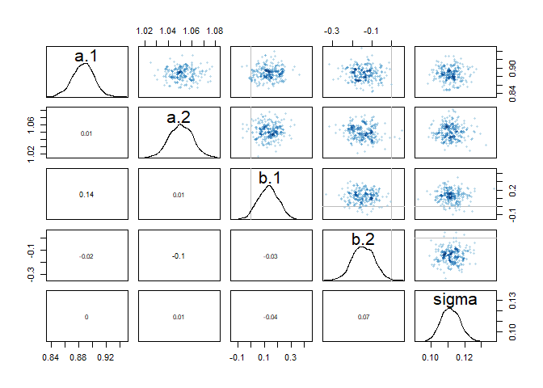

```r
## R code 9.17
pairs( m9.1_0.01 )
```

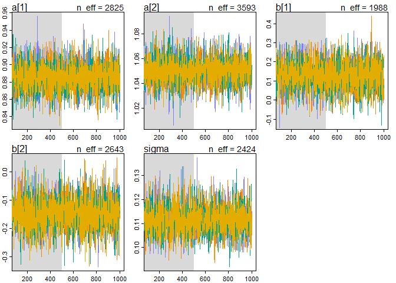

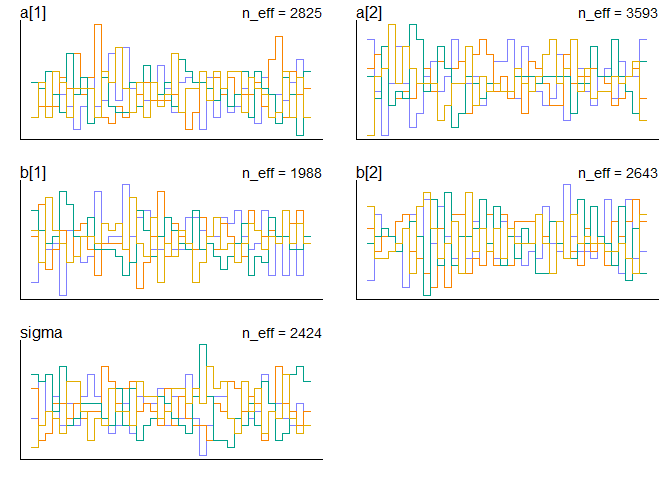

```r
## R code 9.18
traceplot( m9.1_0.01 )

trankplot( m9.1_0.01 , n_cols=2 )
```